# Fixed vs Mixed Effects Models: A Comparative Analysis of Group-Level Variation

Nathan Pavey

2026-07-07

## Introduction

Many datasets contain observations that are naturally grouped, such as students within schools or firms observed across multiple years. In these settings, it is important to determine whether accounting for group-level variation improves model performance.

This project compares fixed effects and mixed effects models using data on UK firms. The objective is to investigate whether modelling random variation within firms improves explanatory and predictive performance.

## Data

```r
data = read.csv("UKFirms.csv")
data$firm = factor(data$firm)
```

The dataset contains annual observations on UK firms including:

- Firm
- Year
- Value
- Capital
- Investment

The firm variable is treated as a grouping factor, allowing both fixed and random effects specifications to be considered.

### Exploratory Analysis

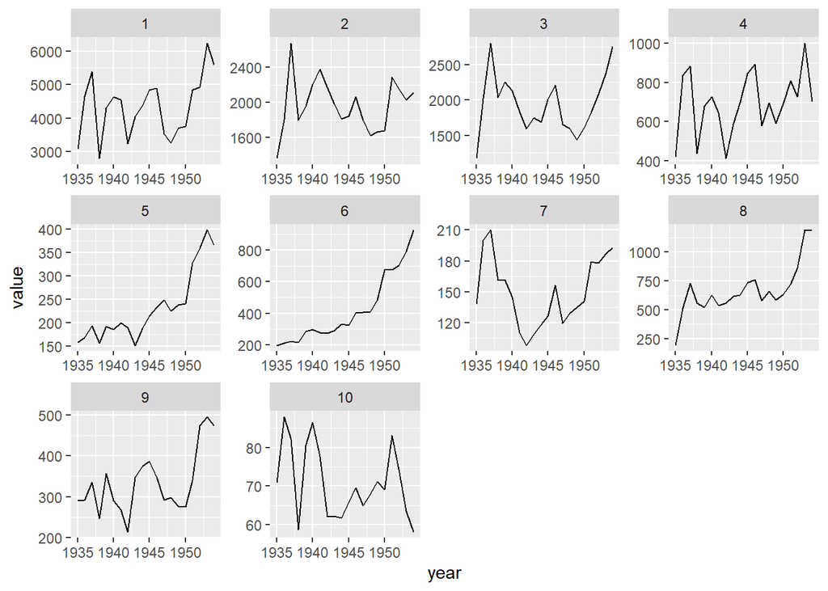

```r
ggplot(data ,aes(x = year, y = value)) +
  geom_line() +
  facet_wrap(~ firm, scales = "free")
```

Initial observations indicate significant differences in the value over time, suggesting that firm specific effects may play a role in modelling the data.

### Fixed Effects Modelling

Fitting a baseline fixed effect model for value, with every dependent variable included (M1).

```r
M1 = lm(value ~ capital + year + inv + firm, data = data)
summary(M1)
```

```
##
## Call:
## lm(formula = value ~ capital + year + inv + firm, data = data)
##
## Residuals:
##     Min      1Q  Median      3Q     Max
## -831.90  -94.24  -14.36   87.51 1364.00
##
## Coefficients:
##               Estimate Std. Error t value Pr(>|t|)
## (Intercept) -1.393e+04  8.599e+03  -1.620   0.1070
## capital     -6.909e-01  1.677e-01  -4.120 5.69e-05 ***
## year         8.695e+00  4.435e+00   1.960   0.0514 .
## inv          2.964e+00  3.101e-01   9.557  < 2e-16 ***
## firm2       -2.021e+03  9.403e+01 -21.490  < 2e-16 ***
## firm3       -1.065e+03  1.532e+02  -6.951 5.88e-11 ***
## firm4       -2.458e+03  1.389e+02 -17.694  < 2e-16 ***
## firm5       -2.595e+03  1.719e+02 -15.100  < 2e-16 ***
## firm6       -2.652e+03  1.448e+02 -18.320  < 2e-16 ***
## firm7       -2.753e+03  1.601e+02 -17.202  < 2e-16 ***
## firm8       -2.377e+03  1.466e+02 -16.207  < 2e-16 ***
## firm9       -2.564e+03  1.602e+02 -16.012  < 2e-16 ***
## firm10      -2.914e+03  1.519e+02 -19.178  < 2e-16 ***
## ---
## Signif. codes:  0 '***' 0.001 '**' 0.01 '*' 0.05 '.' 0.1 ' ' 1
##
## Residual standard error: 266.7 on 187 degrees of freedom
## Multiple R-squared:  0.9613, Adjusted R-squared:  0.9588
## F-statistic: 387.2 on 12 and 187 DF,  p-value: < 2.2e-16
```

Clearly the R^2 is 0.9613 and the adjusted R^2 is 0.9588

The model achieved an adjusted R-squared of 0.959, indicating that a large proportion of the variation in the model is explained by these initial variables.

```r
anova(M1)
```

```
## Analysis of Variance Table
##
## Response: value
##            Df    Sum Sq   Mean Sq F value    Pr(>F)
## capital     1  82120059  82120059 1154.31 < 2.2e-16 ***
## year        1  15524659  15524659  218.22 < 2.2e-16 ***
## inv         1 161358659 161358659 2268.13 < 2.2e-16 ***
## firm        9  71531386   7947932  111.72 < 2.2e-16 ***
## Residuals 187  13303522     71142
## ---
## Signif. codes:  0 '***' 0.001 '**' 0.01 '*' 0.05 '.' 0.1 ' ' 1
```

Test whether the firm variable plays a significant role in modelling the value, conducting a Hypothesis test with

**H0**: firm 1 = firm 2 = … = firm 10.

**H1**: firm i is not equal to firm j for some i,j where, i,j = 1,2,…,10

Since the ANOVA table is sequential F-value of firm given the other three variables are included = 111.72.

P-value = 2.2e-16 << 0.05, therefore reject the null hypothesis, so the firm variable is still siginificant, a firm is still a significant variable.

To investigate whether interaction effects improved model performance, a larger candidate model containing interactions between firm and the explanatory variables was considered:

```r
full_model = lm(value ~ firm + year + inv + capital + firm:year + firm:inv + firm:capital, data = data)
M2 = step(M1, scope = list(upper = full_model, lower = M1), direction = "both")
```

```
## Start:  AIC=2247.04
## value ~ capital + year + inv + firm
##
##                Df Sum of Sq      RSS    AIC
## + firm:year     9   2127043 11176479 2230.2
## + firm:capital  9   1941452 11362070 2233.5
## + firm:inv      9   1909739 11393784 2234.1
## <none>                      13303522 2247.0
##
## Step:  AIC=2230.2
## value ~ capital + year + inv + firm + year:firm
##
##                Df Sum of Sq      RSS    AIC
## <none>                      11176479 2230.2
## + firm:inv      9    700095 10476384 2235.3
## + firm:capital  9    583836 10592644 2237.5
## - year:firm     9   2127043 13303522 2247.0
```

```r
n = nrow(data)
M3 = step(M1, scope = list(upper = full_model, lower = M1), direction = "both", k=log(n))
```

```
## Start:  AIC=2289.92
## value ~ capital + year + inv + firm
##
##                Df Sum of Sq      RSS    AIC
## <none>                      13303522 2289.9
## + firm:year     9   2127043 11176479 2302.8
## + firm:capital  9   1941452 11362070 2306.1
## + firm:inv      9   1909739 11393784 2306.6
```

The two models were evaluated using:

- Adjusted R-squared
- Leave-one-out cross-validation (LOOCV) mean squared prediction error (MSPE),
- 10-fold cross-validation MSPE.

```r
eM1 = resid(M1)
hM1 = hatvalues(M1)
MSPEM1 = mean((eM1/(1-hM1))^2)
eM2 = resid(M2)
hM2 = hatvalues(M2)
MSPEM2 = mean((eM2/(1-hM2))^2)
```

```r
set.seed(540697582)
K = 10
n = nrow(data)
folds = sample(rep(1:K, length.out = n))
ekM1 = numeric(n)
ekM2 = numeric(n)
for (k in (1:K)){
  train = data[folds != k,]
  test = data[folds == k,]
  fitM1 <- lm(value ~ capital + year + inv + firm,
            data = train)
  fitM2 <- lm(value ~ capital + year + inv + firm + year:firm,
            data = train)
  predictionM1 = predict(fitM1, newdata = test)
  predictionM2 = predict(fitM2, newdata = test)
  ekM1[folds == k] = (test$value - predictionM1)^2
  ekM2[folds == k] = (test$value - predictionM2)^2
  MSPEKM1 = mean(ekM1)
  MSPEKM2 = mean(ekM2)
}
```

Comparing all three evaluation methods

```r
data.frame(Model = c("M1","M2"), Adjusted_R2 = c(summary(M1)$adj.r.squared,summary(M2)$adj.r.squared), "MSPE Leave one out" = c(MSPEM1,MSPEM2), "MSPE 10-fold cross validation" = c(MSPEKM1,MSPEKM2))
```

```
##   Model Adjusted_R2 MSPE.Leave.one.out MSPE.10.fold.cross.validation
## 1    M1   0.9588259           80316.90                      81033.61
## 2    M2   0.9636601           83497.35                      86888.83
```

Although the interaction model M2 achieved a slightly higher adjusted R-squared the original fixed effects model M1 produced lower prediction errors under both leave-one-out and 10-fold cross-validation. This suggests that the additional interaction terms improve fit within the sample but do not translate into improved unseen predictive performance, therefore M2 may be overfitting the data. Consequently, the simpler model M1 is preferred on predictive grounds.

### Mixed Effect Model

To account for unobserved heterogeneity between firms, two mixed effects models were considered

1. **Random Intercept Model**

```
value∼year+capital+inv+(1∣firm)
```

2. **Random Intercept and Slope Model**

[output not shown]

The random intercept model allows each firm to have its own baseline level of value, while the random slope model additionally allows for the relationship between value and year to vary across firms.

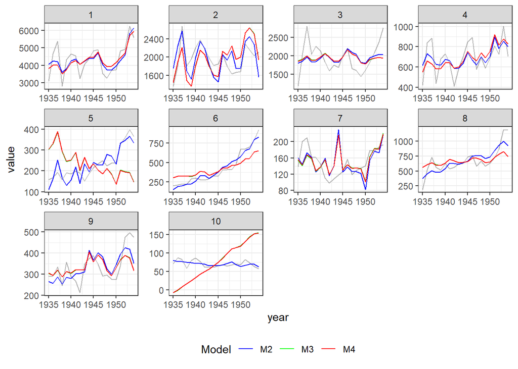

```r
data$M2_fit = fitted(M2)
data$M3_fit = fitted(M3)
data$M4_fit = fitted(M4)
ggplot(data, aes(x = year, y = value)) +
  geom_line(aes(group = firm), alpha = 0.3) +
  geom_line(aes(y = M2_fit, color = "M2", group = firm)) +
  geom_line(aes(y = M3_fit, color = "M3", group = firm)) +
  geom_line(aes(y = M4_fit, color = "M4", group = firm)) +
  facet_wrap(~ firm, scales = "free") +
  scale_color_manual(values = c(
    "M2" = "blue",
    "M3" = "green",
    "M4" = "red"
  )) +
  labs(color = "Model") +
  theme_bw() +
  theme(legend.position = "bottom")
```

### Predictive Performance

```r
trainwc = data[data$year >= 1935 & data$year <= 1950, ]
testwc = data[data$year >= 1951 & data$year <= 1954, ]
M2_train = lm(value ~ capital + year + inv + firm + year:firm, data = trainwc)
M4_train = lmer(value ~ year + capital + inv + (1 + year|firm), data = trainwc, REML = TRUE)
M2_test = predict(M2_train, newdata = testwc)
M4_test = predict(M4_train, newdata = testwc)
testwc$M2_pred = M2_test
testwc$M4_pred = M4_test
head(testwc[, c("firm", "year", "value", "M2_pred", "M4_pred")])
```

```
##    firm year  value  M2_pred  M4_pred
## 17    1 1951 4833.0 4046.278 4022.330
## 18    1 1952 4924.9 4355.240 4198.551
## 19    1 1953 6241.7 5705.885 5134.262
## 20    1 1954 5593.6 6001.066 5182.234
## 37    2 1951 2289.5 2418.868 2598.798
## 38    2 1952 2159.4 2523.700 2668.430
```

```r
MSPE_M2 = mean((testwc$value - testwc$M2_pred)^2)
MSPE_M4 = mean((testwc$value - testwc$M4_pred)^2)
data.frame(Model = c("M2","M4"), MSPE = c(MSPE_M2,MSPE_M4))
```

```
##   Model     MSPE
## 1    M2 121750.3
## 2    M4 179666.5
```

The fixed effects model (M2) and the random effects model (M4) were fitted using the training data and then used to predict firm values in the test period. Predictive performance was assessed using the mean squared prediction error (MSPE).

The fixed effects model achieved a lower MSPE than the mixed effects model, indicating a better predictive peformance. This suggests that, for this dataset, the additional complexity introduced by the random effects specification does not translate into improved model fit, highlighting a key concept that more is not always better.